# Homework 1

*For all questions involving histograms, choose a sensible binwidth and breakpoints, unless otherwise indicated.*

### 1. Income

1. Describe in detail the features you observe in the boxplots below, plotted with data from the *ex0525* dataset, **Sleuth3** page. (see page 29 in *Graphical Data Analysis in R* for a list of features to concentrate on, and the numbered list on the bottom of page 43 for an example of how to describe features of a graph in words.) [5 points]

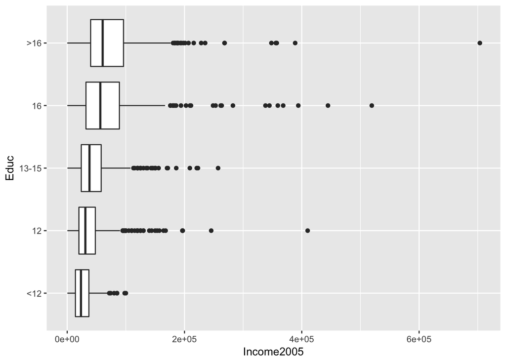

```r
#install.packages("Sleuth3")
library(Sleuth3)
library(tidyverse)

# convert Educ from an integer to a factor, and make "<12" the first factor level
mydata <- ex0525 %>%
  dplyr::mutate(Educ = forcats::fct_relevel(Educ, "<12"))

ggplot(mydata, aes(Educ, Income2005)) +
  geom_boxplot() +
  coord_flip()   # for horizontal boxplots
```

Answer: Every boxplot has the big outliers and all of them the distribution are right-skewed. Comparing with these five boxplot, we can see that: 1.The group with longer years of education have higher income than the group with shorter years if education. 2.The group with longer years of education have has more extreme outliers of income than the group with shorter years if education. 3.The group with longer years of education have has more more dispersedly distribuation of income than the group with shorter years if education.

2. Plot a histogram of the `Income2005` variable in the dataset referenced in part a). [3 points]

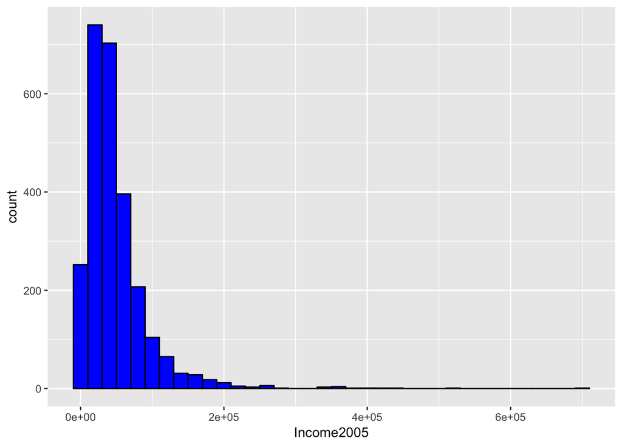

```r
ggplot(mydata, aes(Income2005)) + geom_histogram(color = "black", fill = "blue", binwidth = 20000)
```

3. Use `+facet_wrap(~Educ)` to facet the histogram on education level. [3 points]

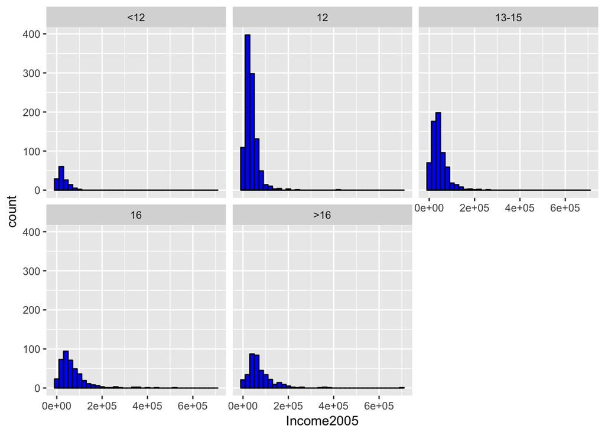

```r
ggplot(mydata, aes(Income2005)) + geom_histogram(color = "black", fill = "blue", binwidth = 20000) + facet_wrap(~Educ)
```

### 2. Respiratory Rates

1. Plot right closed and right open histograms for each of the two variables in the *ex0824* dataset in the **Sleuth3** package using default binwidths and breaks. (4 histograms in total). [4 points]

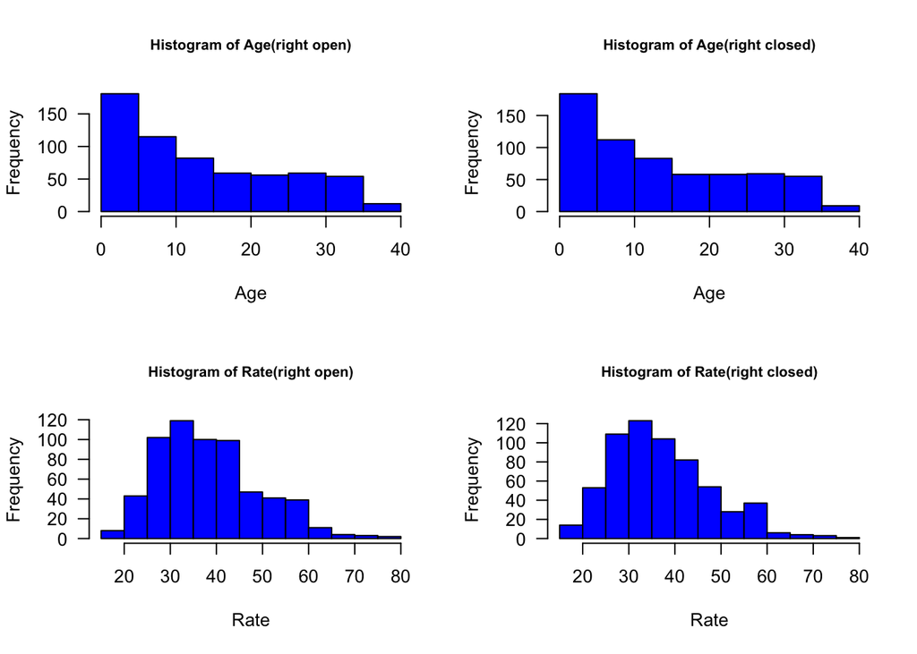

```r
data2 <- ex0824
par(mfrow = c(2, 2), las = 1)
Histogram = hist(data2$Age, col = "blue", right = FALSE, xlab = 'Age', main = 'Histogram of Age(right open)', cex.main = 0.8)
hist(data2$Age, col = "blue", left = FALSE, xlab = 'Age', main = 'Histogram of Age(right closed)', cex.main = 0.8)
hist(data2$Rate, col = "blue", right = FALSE, xlab = 'Rate', main = 'Histogram of Rate(right open)', cex.main = 0.8)
hist(data2$Rate, col = "blue", left = FALSE, xlab = 'Rate', main = 'Histogram of Rate(right closed)', cex.main = 0.8)
```

2. For which variable, `Age` or `Rate`, do the two versions differ more? Why? [3 points] Answer:

Variable `Rate` differ more.Because the `Age` is decimals,`Rate` are integers. The probability that `Rate` locates on the boundary will larger than `Age`.

3. Redraw the `Age` histograms with different parameters so that the right closed and right open versions are identical. [3 points]

[figure not shown]

```r
par(mfrow = c(1, 2), las = 1)
hist(data2$Age, col = "blue", breaks = Histogram$breaks - 0.1, right = FALSE, xlab = 'Age', main = 'Histogram of Age(right open)', cex.main = 0.8)
hist(data2$Age, col = "blue", breaks = Histogram$breaks - 0.1, left = FALSE, xlab = 'Age', main = 'Histogram of Age(right closed)', cex.main = 0.8)
```

### 3. Movie budgets

Are there rounding patterns in the `budget` variable of the *movies* in the **ggplot2movies** package? If so, what are the patterns? (Note: according to the textbook this dataset is in the **ggplot2** package, but it has since been moved to a separate package.) Support your conclusions with graphical evidence. You are encouraged to break the variable down into different budget ranges and consider them separately. [8 points]

### 4. Finches

1. Plot separate density histograms of the beak depth of the finches in *case0201* from the **Sleuth3** package, with density curves overlaid as on page 34 of the textbook. (However, do this by facetting on `Year` rather than using `grid.arrange`). [3 points]

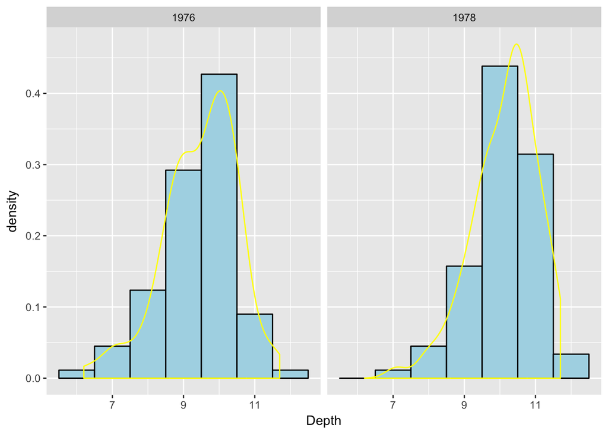

```r
data4 = case0201
ggplot(data4, aes(Depth)) + geom_histogram(aes(y = ..density..), binwidth=1, col = 'black', fill = "lightblue") + geom_density(col = 'yellow') + facet_wrap(~Year)
```

2. Plot both density curves on the same graph to facilitate comparison. Make 1976 yellow and 1978 blue. Use alpha blending so the fills are transparent. [3 points]

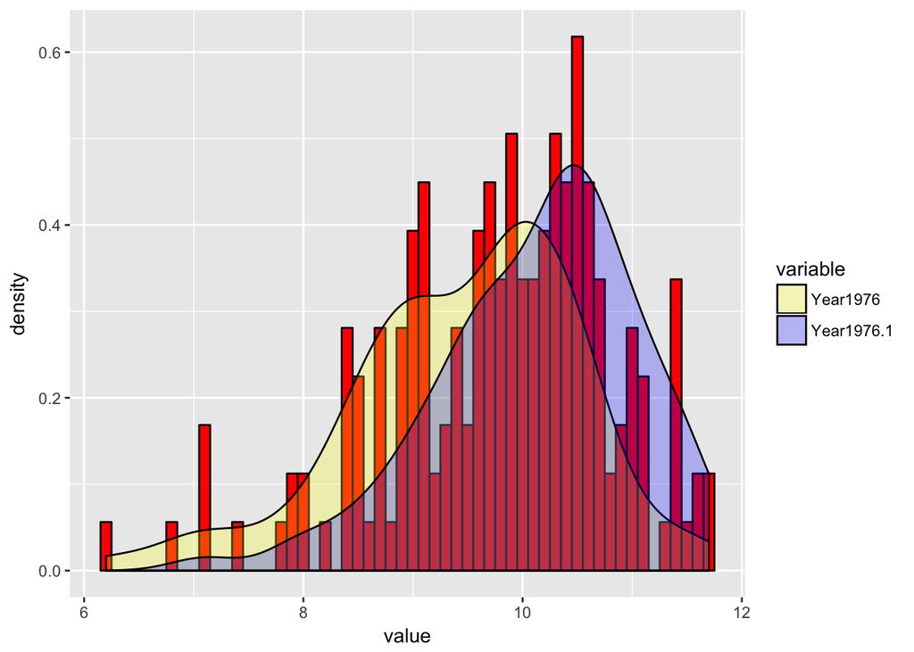

```r
library(ggplot2)
library(reshape2)
x <- data.frame(Year1976 = data4$Depth[data4$Year == '1976'], Year1976 = data4$Depth[data4$Year == '1978'])
newdata <- melt(x)
ggplot(newdata,aes(value, fill=variable)) + geom_histogram(aes(y = ..density..), binwidth=0.1, col = 'black',fill = 'red') + geom_density(alpha=0.25) + scale_fill_manual( values = c("yellow","blue"))
```

3. Based on your graphs in parts a) and b), describe how the distributions differ by year. [3 points]

Answer:

From graps in a) and b), the distributation in 1978 shif to right comparing to distributation in 1976.

4. What is the cause of the difference according to the information in the help file? [3 points]

### 5. Salary

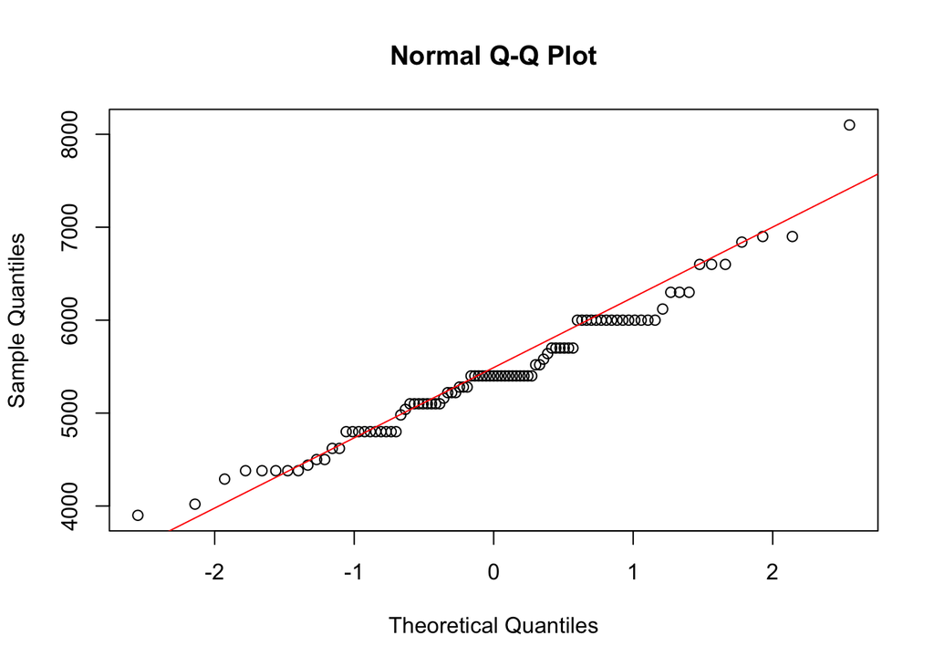

```r
library("ggpubr")
data5 = case0102
qqnorm(data5$Salary)
qqline(data5$Salary, col = 2)
```

The first method I just used qqplots to check the normal distribution.From the Q-Q plot, it is not a very good stright line. This may not a normal distributation.

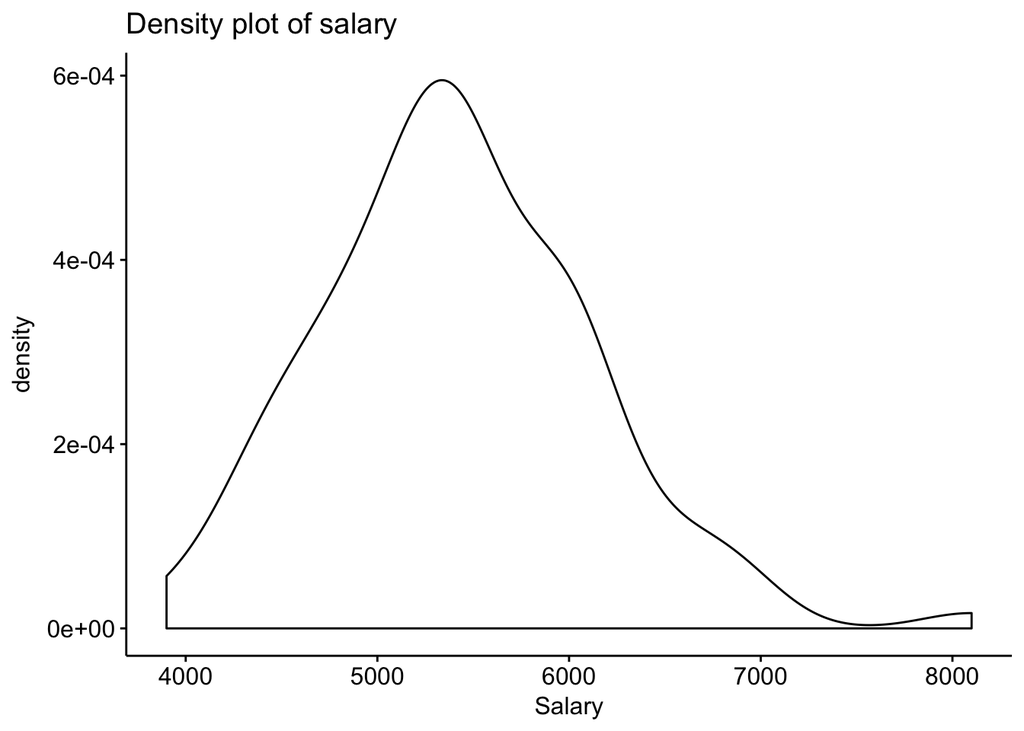

```r
ggdensity(data5$Salary, main = "Density plot of salary", xlab = "Salary")
```

Second I used density plot which the density plot provides a visual judgment about whether the distribution is bell shaped. From the graph it not a perfect bell shaped.

```r
shapiro.test(data5$Salary)
```

```
##
##  Shapiro-Wilk normality test
##
## data:  data5$Salary
## W = 0.96573, p-value = 0.0152
```

From the Shapiro-Wilk normality test, p-value was 0.0152 < 0.05. So we reject the null hypothesis that the salary data is normally distributed.